# Data_Analysis

Idris Iritas

2024-10-23

## Exploratory Data Analysis

In this notebook we use some data visualisation tools to explore a dataset of Albert Heijn products

```r
# Get project root paths
r_project_root <- getwd()
main_project_root <- dirname(r_project_root)
```

Load in the dataset from csv. The dataset used here is provided with the repository.

```r
data_path <- file.path(main_project_root, "complete_datasets", "2024-10-23.csv")

df <- read.csv(data_path)

dim(df)
```

```
## [1] 30498   106
```

This dataset has 30498 rows, or products, and 106 columns, or data features.

What these features are is showcased below

```r
colnames(df)
```

```
##   [1] "ProductId"
##   [2] "ProductName"
##   [3] "PriceRegular"
##   [4] "PriceSale"
##   [5] "Category1"
##   [6] "Category2"
##   [7] "Category3"
##   [8] "Category4"
##   [9] "Category5"
##  [10] "Category6"
##  [11] "ProductUnitSize"
##  [12] "Energie..kcal."
##  [13] "Energie..kJ."
##  [14] "Vet"
##  [15] "waarvan.verzadigd"
```

[output cut: 91 more lines]

A separate column was created for every nutrient encountered during scraping. This makes the dataframe unnecessarily large, as we do not use most of this data. We’ll filter out all nutrients except for Energy values, carbohydrates, sugars, saturated fats, unsaturated fats, total fats, protein, fiber and salt.

```r
df <- df[, -c(22:99)]

dim(df)
```

```
## [1] 30498    28
```

Now we have 28 columns of data. Next we want to be aware of the number of NA values for each column. We have a lot of missing data, such as missing nutrition for non-food items, missing categories and missing ingredients. Let’s count the missing values per feature:

```r
na_counts <- sapply(df, function(x) sum(is.na(x)))

na_counts
```

```
##           ProductId         ProductName        PriceRegular           PriceSale
##                   0                   0                5166               28938
##           Category1           Category2           Category3           Category4
##                6097                6103                7024               15270
##           Category5           Category6     ProductUnitSize      Energie..kcal.
##               26866               30335                   8               14547
##        Energie..kJ.                 Vet   waarvan.verzadigd waarvan.onverzadigd
##               14547               14764               14795               24655
##        Koolhydraten     waarvan.suikers       Voedingsvezel            Eiwitten
##               14766               14777               19832               14763
##                Zout         Ingredients  ContainedAllergens MayContainAllergens
##               14812               10974               18102               24531
##  NonFoodIngredients         ImageLowURL      ImageMediumURL        ImageHighURL
##               27164                4239                4239                4239
```

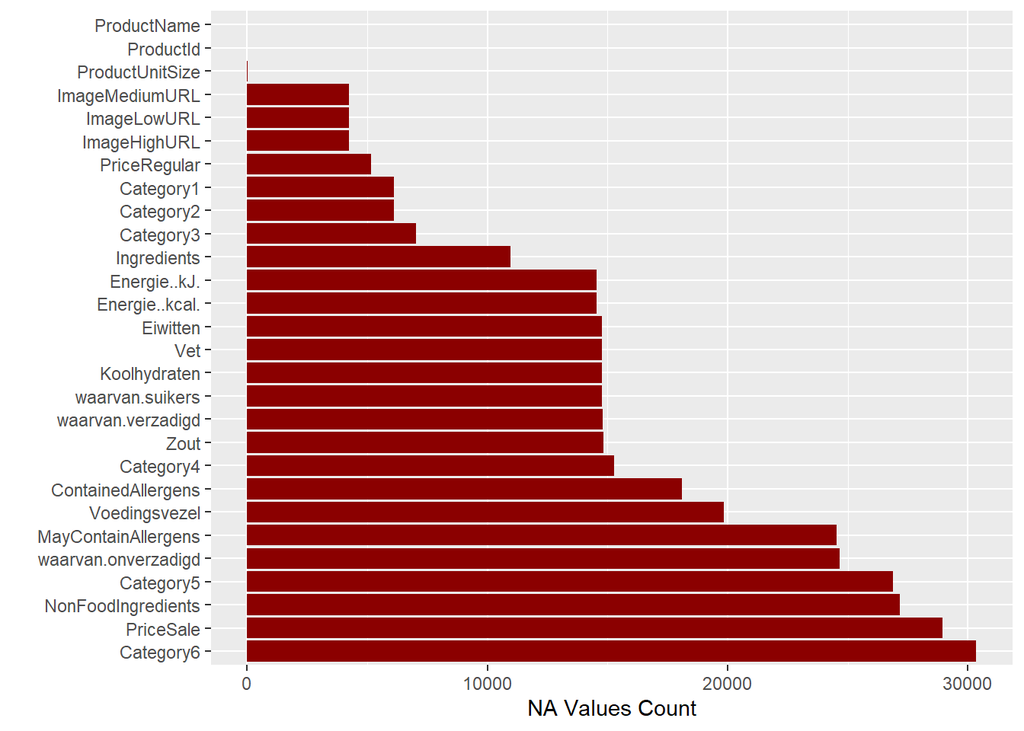

```r
# Convert the named vector to a dataframe
na_df <- data.frame(Names = names(na_counts), Values = as.numeric(na_counts))

# Create the bar plot, sorted by Values in descending order
ggplot(na_df, aes(x = reorder(Names, -Values), y = Values)) +
  geom_bar(stat = "identity", fill = "darkred") +
  coord_flip() + # Flip the plot for better readability
  labs(x = "", y = "NA Values Count")
```

We observe that there is not much variation in the NA count for the nutrients: Energy, Carbohydrates, Sugars, Fats, Saturated fats, Protein and Salt. We can create a data-frame for values that have these nutrients labeled. But we have to do some data cleaning. The data is suffixed with units like “g” and “mg” and sometimes prefixed with “<”. Let’s check which units exist for the nutritional columns

```r
# Function to check if only 'g' is present
check_units <- function(column) {

  # Extract unique units using regular expression
  units <- unique(gsub(".*?(g|kg|mg|l).*", "\\1", column))
  return(unique(units))

}

# Apply the function to each nutritional column
result <- sapply(df[, c(14:21)], check_units)

# Print results
print(result)
```

```
## $Vet
## [1] "g" NA
##
## $waarvan.verzadigd
## [1] "g" NA
##
## $waarvan.onverzadigd
## [1] "g" NA
##
## $Koolhydraten
## [1] "g" NA
##
## $waarvan.suikers
## [1] "g" NA
##
## $Voedingsvezel
## [1] "g" NA
##
## $Eiwitten
## [1] "g" NA
##
## $Zout
## [1] "g"  NA   "mg"
```

We observe that g is the only unit used for all columns except for salt.

Let’s parse all the columns with only g, then handle the salt column afterwards:

```r
# Store these values for a sanity check
old_values <- df$Koolhydraten[c(4328, 4619, 12249, 12697, 23202, 21876)]


# Loop through columns 14 to 20
for (col in 14:20) {
  # Remove " g" and handle special cases like "< something g"
  cleaned_values <- gsub(" g", "", df[[col]])

  # Replace any values that start with "<" with NA
  cleaned_values <- ifelse(grepl("^<", cleaned_values), 0, cleaned_values)

  # Convert to numeric
  df[[col]] <- as.numeric(cleaned_values)
}

# Store these values for a sanity check
new_values <- df$Koolhydraten[c(4328, 4619, 12249, 12697, 23202, 21876)]
```

To check the result of our processing, we took a few indices as test-cases:

```r
aligned_output <- data.frame(Raw = old_values, Processed = new_values)

aligned_output
```

```
##        Raw Processed
## 1    < 0 g      0.00
## 2 < 0.01 g      0.00
## 3   < 19 g      0.00
## 4     94 g     94.00
## 5   97.8 g     97.80
## 6  99.45 g     99.45
```

It is important to note that with our rule-set of converting < x to 0, we also convert <19 g to 0.

Now to handle the salt column, we perform the same parsing operation as before, except now we also divide by 1000 if we encounter mg to have all data as the same unit: grams.

```r
old_salt_values <- df$Zout[c(23254, 263, 9090, 7928, 19921, 2, 250)]

# Remove " g" and handle special cases like "< something g" and milligrams
cleaned_values <- gsub(" mg", "", df$Zout)   # Remove " mg" for easier processing
cleaned_values <- gsub(" g", "", cleaned_values)  # Remove " g" for easier processing

# Replace any values that start with "<" with 0
cleaned_values <- ifelse(grepl("^<", cleaned_values), 0, cleaned_values)

# Convert to numeric and handle mg
df$Zout <- ifelse(grepl("mg$", df$Zout), as.numeric(cleaned_values) / 1000, as.numeric(cleaned_values))

new_salt_values <- df$Zout[c(23254, 263, 9090, 7928, 19921, 2, 250)]
```

We can perform another sanity check below, and we see that the values were all converted correctly.

```r
aligned_salt_output <- data.frame(Raw = old_salt_values, Processed = new_salt_values)
aligned_salt_output$Processed <- sprintf("%.4f", aligned_salt_output$Processed)

aligned_salt_output
```

```
##         Raw Processed
## 1      0 mg    0.0000
## 2    0.2 mg    0.0002
## 3     10 mg    0.0100
## 4  < 0.01 g    0.0000
## 5 < 0.025 g    0.0000
## 6     2.9 g    2.9000
## 7    99.9 g   99.9000
```

Now that our numerical nutrition data is processed, let’s create a new data-frame that excludes all NA values for our aforementioned nutrients.

```r
# Create the subset of df with the specified columns
nutrition_df <- df[, c("ProductId", "ProductName", "Energie..kcal.", "Vet",
                        "waarvan.verzadigd", "Koolhydraten",
                        "waarvan.suikers", "Eiwitten", "Zout")]

nutrition_df <- na.omit(nutrition_df)

head(nutrition_df)
```

```
##    ProductId                            ProductName Energie..kcal.  Vet
## 1         73                    AH Franse baguettes            241  1.0
## 2        103      Lea & Perrins Worcestershire saus             96  0.9
## 3        107                  AH Aardappelballetjes            137  4.4
## 4        123 Campina Halfvolle yoghurt vanillesmaak             78  1.6
## 7        257                AH Roomkaas met kruiden            288 28.0
## 11       309                AH Fruitcocktail siroop             49  0.1
##    waarvan.verzadigd Koolhydraten waarvan.suikers Eiwitten Zout
## 1                0.2         50.0             3.3      7.2 0.90
## 2                0.4         21.0            19.0      0.8 2.90
## 3                0.5         21.0             0.7      2.2 0.70
## 4                1.1         12.2            11.0      3.1 0.11
## 7               18.0          4.4             4.2      4.6 1.40
## 11               0.1         11.0             9.8      0.4 0.03
```

```r
error_indices <- !is.na(df$Energie..kcal.) & !is.na(df$Energie..kJ.) & (df$Energie..kcal. > df$Energie..kJ.)

error_products <- df[error_indices, c("ProductName", "Energie..kcal.", "Energie..kJ.")]

print(error_products)
```

```
##                                      ProductName Energie..kcal. Energie..kJ.
## 8315                    Osem Sunny wheat cracker           1822          433
## 8537                       Klilah Hummus classic           1225          301
## 8538                       Klilah Tahini classic           1049          251
## 8541                 Klilah Aubergine babaganush           1132          271
## 8542                     Klilah Aubergine tahini            750          180
## 8543            Klilah Spanish piquant aubergine            750           85
## 8545               Klilah Spicy Moroccan carrots            355           85
## 8546                     Klilah Hummus & harissa           1225          301
## 8547                     Klilah Hummus masabacha           1049          251
## 8548                 Klilah Hot Tunisian harissa           1475          353
## 13693                       Marhaba Rundersalami           2302         1254
## 14412         Zanetti Parmigiano Reggiano flakes            402          167
## 16426                    Marqués de Requena Brut            314           75
## 20261 Flower Farm Hazelnootpasta zonder palmolie           2288          547
## 20634                     LambWeston Grill fries            772          173
## 23112          Ghaia Surinaamse roti gele erwten            963          228
## 25026        Butcha Rasberry rose & black tea 0%             10            2
## 25741                   Sella & Mosca Vermentino            293           70
## 26680               Knorr Spaghetteria formaggio            435          104
## 26683                                So fab Rosé            312           75
## 27231                 AH Danish pastry raspberry           1438          344
## 27841       Garden Gourmet Sensational chipolata            877          212
## 27842         Garden Gourmet Sensational merguez            869          210
## 30391                 Bonne Maman Chocolate cake           1896          456
```